# Exercice R et Stat Des

Christophe Ambroise

2024-03-04

# Simulation de lois

## Loi uniforme: simulation

Simuler 100 réalisation d’une loi uniforme

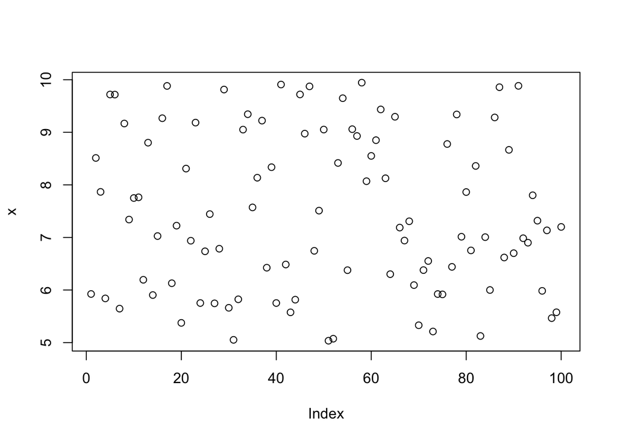

```r
set.seed(2)
x<-runif(100,5,10)
plot(x)
```

et compter combien de valeurs simulées sont au dessus d’un seuil

```r
compteur<-0
for(value in x) if(value>=7) compteur<-compteur+1
print(compteur)
```

```
## [1] 56
```

En version courte

```r
# Version courte
sum(x>=7)
```

```
## [1] 56
```

## Loi Gaussienne

1. Simuler 300 valeurs de QI qui suivent une loi normale
   $$QI \sim \mathcal{N} (\mu=100, \sigma=15)$$
2. Estimer la proportion de valeurs
- supérieures à 130
- inférieures à 100

```r
QI<-rnorm(300,mean=100,sd=15)
mean(QI<100)
```

```
## [1] 0.4666667
```

```r
mean(QI>130)
```

```
## [1] 0.03333333
```

3. Calculer la valeur théorique de ces proportions

$$\begin{align}
P(QI>130) & = P(\frac{QI-100}{15}>\frac{130-100}{15})\\
& = P(\frac{QI-100}{15}>2)\\
& = 1 - P(\frac{QI-100}{15}\leq 2)\\
& = 1 -P(U \leq 2)\\
& = 1- \phi(2)\\
& = \phi(-2)
\end{align}$$
avec $U \sim \mathcal N(0,1)$.

```r
print(pnorm(130,mean=100, sd=15,lower.tail = FALSE))
```

```
## [1] 0.02275013
```

```r
print(1 - pnorm(2))
```

```
## [1] 0.02275013
```

```r
print(pnorm(-2))
```

```
## [1] 0.02275013
```

4. Utiliser ces calculs pour illustrer la loi des grands nombres

La loi des grands nombres nous dit que

$$\frac{1}{n}\sum_{j=1}^n \mathbb{I}_{QI_j >130}
\stackrel{p.s.}{\longrightarrow} E(\mathbb I_{QI_j}>130) = p_{130}$$
Si on augmente la taille d’échantillon et que l’on calcule la proportion empirique:

```r
taille.echantillon<-c(10,100,1000,10000,100000)
for (n in taille.echantillon){print(mean(rnorm(n=n,mean=100,sd=15)>130))}
```

```
## [1] 0.1
## [1] 0.03
## [1] 0.025
## [1] 0.0238
## [1] 0.02265
```

# Prétraitement

## Outliers (données abberantes)

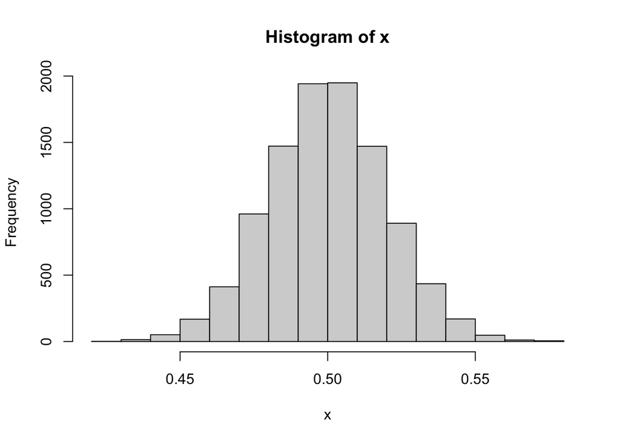

```r
# Simulation de 10,000 tailles
x<-rnorm(10000,mean=0.5,sd=2/100)
hist(x)
```

```r
x<- c(x,5/100,5)
```

Estimons la moyenne et l’écart type de l’échantillon et prenons k=4

```r
# Simulons 1000 taille de nourissons suivant une loi normale
x<-rnorm(1000,mean=50,sd=2)
# Ajoutons deux erreurs (1 bébé trop petit, 1 trop grand)
c(x,4.8,510)->x

# Estimons la moyenne et l'écart de l'échantillon des 1002 bébés
mu.hat<-mean(x)
sd.hat<-sqrt(var(x))

k<-4
print(outliers.min<- mu.hat - k*sd.hat)
```

```
## [1] -8.577834
```

```r
print(outliers.max<- mu.hat + k*sd.hat)
```

```
## [1] 109.4141
```

```r
x[(x<outliers.min)|(x> outliers.max)]
```

```
## [1] 510
```

Calculons la moyenne et la variance tronquée en utilisant un paramètre trim qui donne le pourcentage d’observations extrêmes non pris en compte…

```r
trim<-0.01
n<-length(x)
k<-round(n*trim)
x.trimmed <-sort(x)[(k+1):(n-k)]
mu.hat<-mean(x.trimmed)
sd.hat<-sqrt(var(x.trimmed))


sd.trim<-function(x,trim=0.05){
  n<-length(x)
  k<-round(n*trim)
  x.trimmed <-sort(x)[(k+1):(n-k)]
  sd.hat<-sqrt(var(x.trimmed))
}




k<-4
print(outliers.min<- mu.hat - k*sd.hat)
```

```
## [1] 42.18132
```

```r
print(outliers.max<- mu.hat + k*sd.hat)
```

```
## [1] 57.81216
```

```r
x[(x<outliers.min)|(x> outliers.max)]
```

```
## [1]  58.3388   4.8000 510.0000
```

```r
which((x<outliers.min)|(x> outliers.max))
```

```
## [1]   49 1001 1002
```

# Fonction

Ecrire une fonction qui prend en argument un échantillon, la variable trim qui indique le pourcentage d’observations à supprimer, et qui rende en sortie, la moyenne tronquée et l’écart type tronqué.

```r
stat.trimmed<-function(x,trim=0.05){
  n<-length(x)
  k<-round(n*trim)
  x.trimmed<-sort(x)[(k+1):(n-k)]
  return(list(mean.trimmed=mean(x.trimmed),
              sd.trimmed=sqrt(var(x.trimmed))))
}


# simulons un échantillon
x<-c(rnorm(100,50,2),600)
print(stat.trimmed(x))
```

```
## $mean.trimmed
## [1] 50.14574
##
## $sd.trimmed
## [1] 1.508397
```

```r
print(paste("Moyenne classique",mean(x)))
```

```
## [1] "Moyenne classique 55.521587552483"
```

```r
print(paste("Moyenne tronquée",stat.trimmed(x)$mean.trimmed))
```

```
## [1] "Moyenne tronquée 50.1457440590004"
```

```r
print(paste("Ecart type classique",sd(x)))
```

```
## [1] "Ecart type classique 54.7485544087614"
```

```r
print(paste("Ecart type tronquée",stat.trimmed(x,trim=0.02)$sd.trimmed))
```

```
## [1] "Ecart type tronquée 1.64596360926422"
```

# Calcul par groupe

Simulons deux groupes, un de 45 femmes et l’autre de 60 hommes, et des tailles associées à chaque individu

- La taille des femmes suit $\mathcal N(\mu=168,\sigma=5)$
- La taille des hommes suit $\mathcal N(\mu=178,\sigma=6)$

```r
sex<-rep(c("H","F"),c(60,45))
# Forçons le type
sex<-as.factor(sex)
Tailles<-c(rnorm(60,mean=178,sd=6),rnorm(45,168,5))
# la fonction tapply applique une fonction (ici mean) à un vecteur (Tailles ) suivant les groupes définis par un facteur (ici sex)
tapply(Tailles,sex,mean)
```

```
##        F        H
## 168.2313 178.1046
```

```r
tapply(Tailles,sex,function(group){max(group) - min(group)})
```

```
##        F        H
## 16.48933 23.60910
```

# Matrices

Soit un ensemble de bien immobiliers décrits par la surface habitable et la taille du jardin.

Le prix moyen de vente d’un bien est une combinaison linéaire de la surface habitable et de la taille du jardin.

Ecrire une fonction qui prenne une matrice décrivant 100 bien immobiliers et calculer leur prix moyen par une multiplication matricielle.

```r
Surface.maison<-rnorm(100,110,20)
Jardin<-c(rep(0,10),rnorm(90,500,100))
print(Bien.immobilier<-matrix(c(Surface.maison,Jardin),100,2))
```

```
##             [,1]     [,2]
##   [1,] 109.55591   0.0000
##   [2,] 110.57813   0.0000
##   [3,]  94.01510   0.0000
##   [4,] 138.63233   0.0000
##   [5,] 138.14143   0.0000
##   [6,]  89.48352   0.0000
##   [7,] 136.78644   0.0000
##   [8,]  93.85385   0.0000
##   [9,] 118.16659   0.0000
##  [10,] 113.65089   0.0000
##  [11,] 109.06524 513.5764
##  [12,]  92.21736 504.4645
##  [13,]  99.44175 413.0441
##  [14,]  69.33212 460.9178
```

[output cut: 86 more lines]

```r
colnames(Bien.immobilier)<-c("Surface.habitable","Taille.jardin")

Formule.regression<-c(4000,100)

print(Prix<-Bien.immobilier%*% cbind(Formule.regression))
```

```
##        Formule.regression
##   [1,]           438223.6
##   [2,]           442312.5
##   [3,]           376060.4
##   [4,]           554529.3
##   [5,]           552565.7
##   [6,]           357934.1
##   [7,]           547145.8
##   [8,]           375415.4
##   [9,]           472666.4
##  [10,]           454603.6
##  [11,]           487618.6
##  [12,]           419315.9
##  [13,]           439071.4
##  [14,]           323420.3
```

[output cut: 86 more lines]

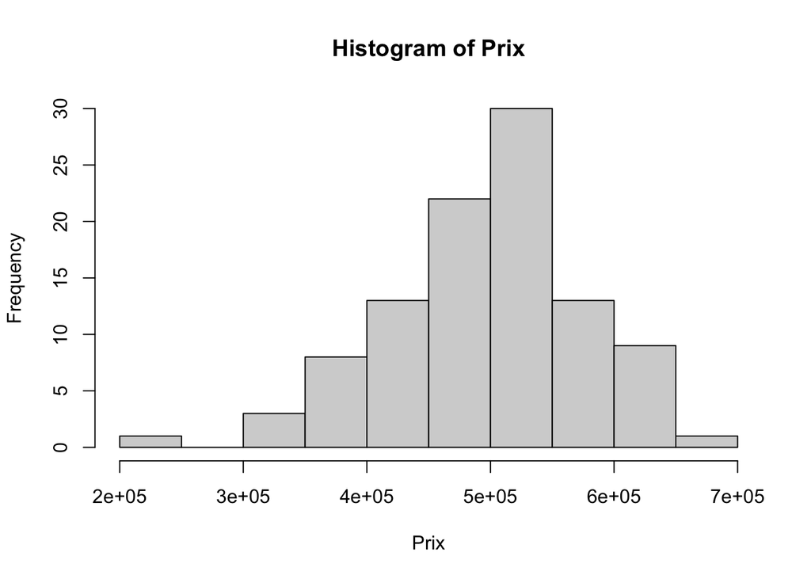

```r
hist(Prix)
```

```r
Estimateur<-function(X,y){
  solve(t(X)%*%X)%*%t(X)%*%y
}

print(Estimateur(X=Bien.immobilier,y=Prix))
```

```
##                   Formule.regression
## Surface.habitable               4000
## Taille.jardin                    100
```

# Listes

Accès aux éléments d’une liste

```r
maliste<-list(A=matrix(0,2,2),B="Christophe",C=TRUE)
str(maliste)
```

```
## List of 3
##  $ A: num [1:2, 1:2] 0 0 0 0
##  $ B: chr "Christophe"
##  $ C: logi TRUE
```

```r
str(maliste[1])
```

```
## List of 1
##  $ A: num [1:2, 1:2] 0 0 0 0
```

```r
str(maliste[[1]])
```

```
##  num [1:2, 1:2] 0 0 0 0
```

Créer une liste d’échantillons de tailles de nourrissons:

- Chaque case de la liste est un échantillon de taille différente.
- La taille de l’échantillon suit une loi de poisson de paramètres 150.
- La liste contient 22 éléments.

```r
# Simulons les tailles d'échantillons
taille.echantillon<-rpois(22,lambda=150)
Hopitaux<-list()
for (i in 1:22) Hopitaux[[i]]<-rnorm(taille.echantillon[i],50,2)

lapply(Hopitaux, min)
```

```
## [[1]]
## [1] 45.13135
##
## [[2]]
## [1] 45.37916
##
## [[3]]
## [1] 44.04215
##
## [[4]]
## [1] 43.34796
##
## [[5]]
## [1] 44.74898
##
## [[6]]
## [1] 43.9133
##
## [[7]]
## [1] 44.03992
##
## [[8]]
## [1] 44.6237
##
## [[9]]
## [1] 44.751
##
## [[10]]
## [1] 42.24569
##
## [[11]]
## [1] 44.84959
##
## [[12]]
## [1] 44.76095
##
## [[13]]
## [1] 44.48031
##
## [[14]]
```

[output cut: 10 more lines]

```
##
## [[18]]
## [1] 46.08784
##
## [[19]]
## [1] 45.28996
##
## [[20]]
## [1] 45.25966
##
## [[21]]
## [1] 45.72968
##
## [[22]]
## [1] 44.33984
```

```r
unlist(lapply(Hopitaux, function(x) max(x)-min(x)))
```

```
##  [1] 10.645082 10.426090 13.596182 11.135801 10.418550 11.013927 11.462580
##  [8] 10.323290 10.618242 14.139971  9.643210 10.543616 10.701138 11.057027
## [15] 11.591177  8.962536 10.982516  9.794923 10.725311  9.273790  9.222000
## [22] 10.407644
```

```r
for (i in 1:length(Hopitaux)) min(Hopitaux[[i]])
```

# Fonction avec plusieurs sorties

```r
stat.des<-function(x){
  return(list(moyenne=mean(x),ecart.type=sd(x)))
}

Tailles<-rnorm(70,50,2)
resultat<-stat.des(Tailles)



stat.trimmed<-function(x,trim=0.1){
  n<-length(x)
  k<-round(trim*n)
  mean.trim<-mean(sort(x)[(k+1):(n-k)])
  sd.trim<-sd(sort(x)[(k+1):(n-k)])
  return(list(mean=mean.trim,sd=sd.trim))
}


echantillon<- c(rnorm(70,50,2),500,600)
stat.trimmed(echantillon)
```

```
## $mean
## [1] 50.02518
##
## $sd
## [1] 1.158833
```

```r
echantillon["case 25"]
```

```
## [1] NA
```

# Variable qualitative ordinale

Calcul des fréquences relatives et cumulées sur la vitesse dans le jeu de données `cars`

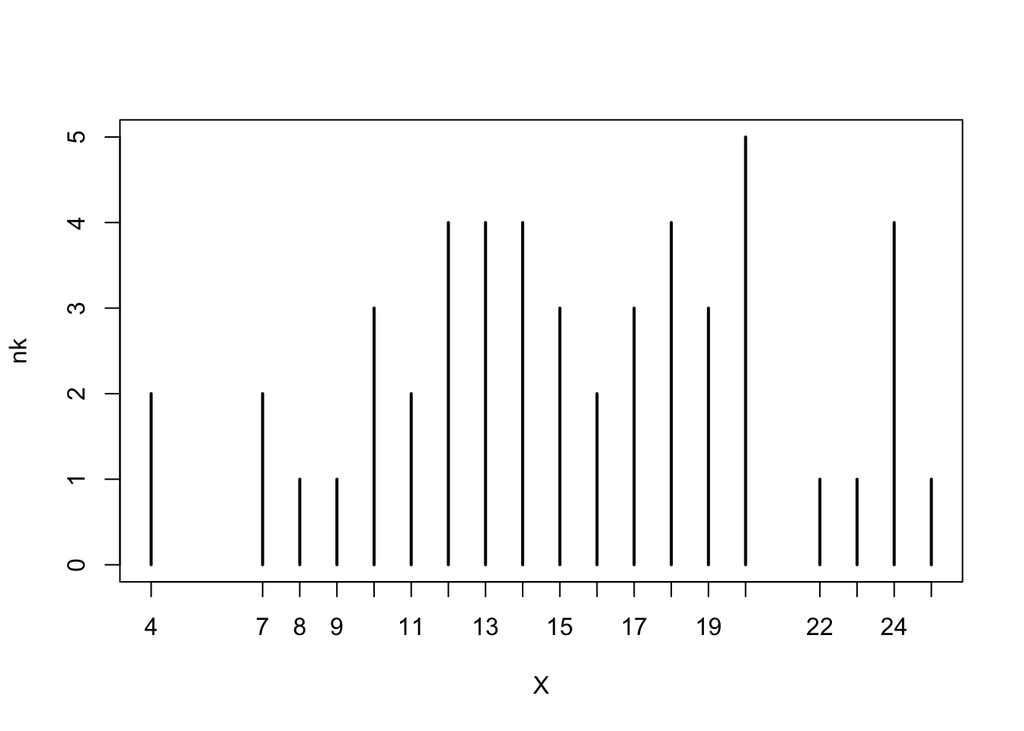

```r
data(cars)
X<-cars$speed
# Les modalités: epsilonk
epsilonk<-unique(X)
# Les effectifs: nk
nk<-table(X)
plot(nk)
```

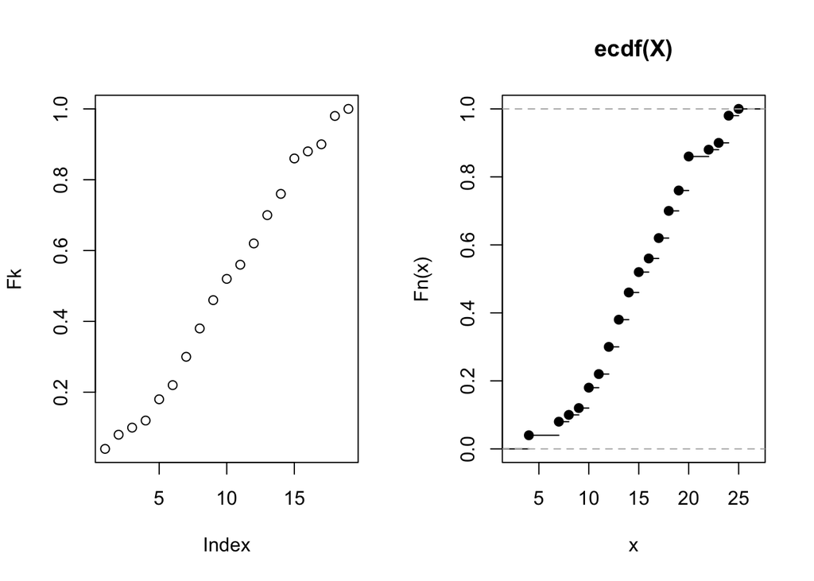

```r
# Les fréquences: fk
fk<-nk/sum(nk)
# Les fréquences cumulées: Fk
Fk<-cumsum(fk)
par(mfrow=c(1,2))
plot(Fk)
plot(ecdf(X))
```

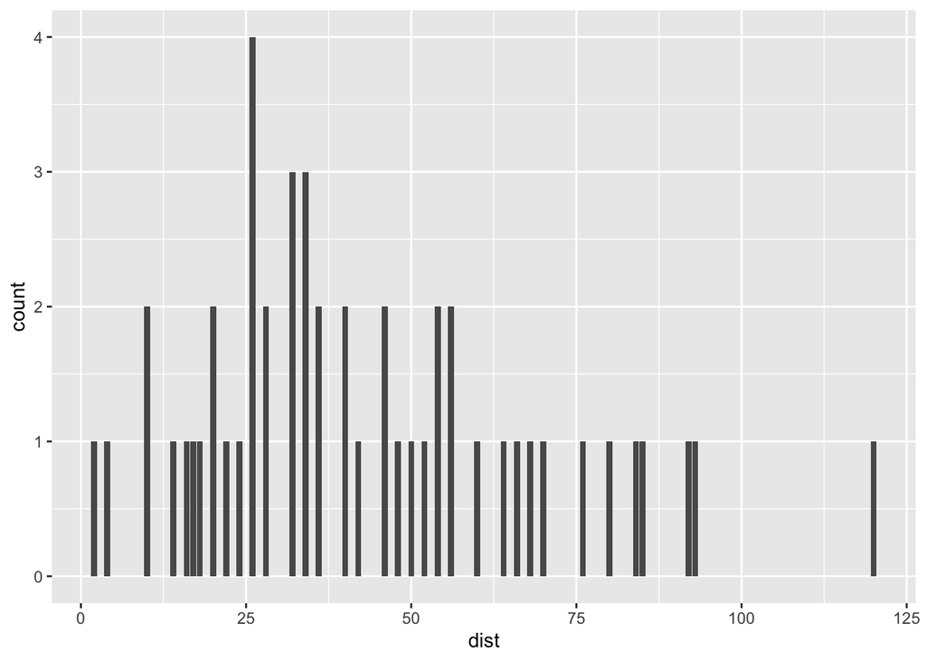

```r
library(ggplot2)
ggplot(data = cars,aes(x=dist))+geom_bar()
```

Quelle proportion d’une variable alétoire normale est définie par l’intervalle $[Q_1-1.5 IQR, Q_3+1.5 IQR]$ ?

```r
Q1<-qnorm(0.25)
Q3<-qnorm(0.75)
IQR<-Q3-Q1
m.inf<- Q1-1.5*IQR
m.sup<- Q3+1.5*IQR
print(pnorm(m.sup)-pnorm(m.inf))
```

```
## [1] 0.9930234
```

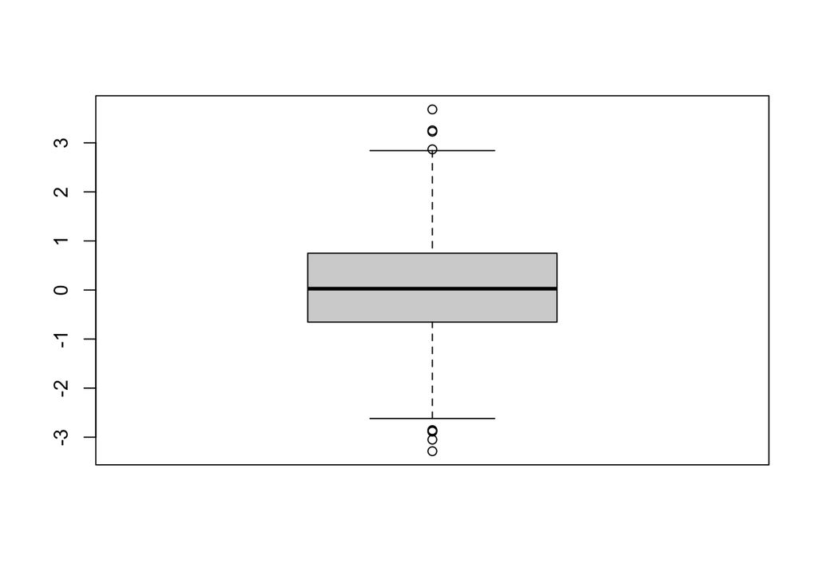

```r
# Boxplot pour distribution normale (symétrique)
X<-rnorm(1000)
boxplot(X)
```

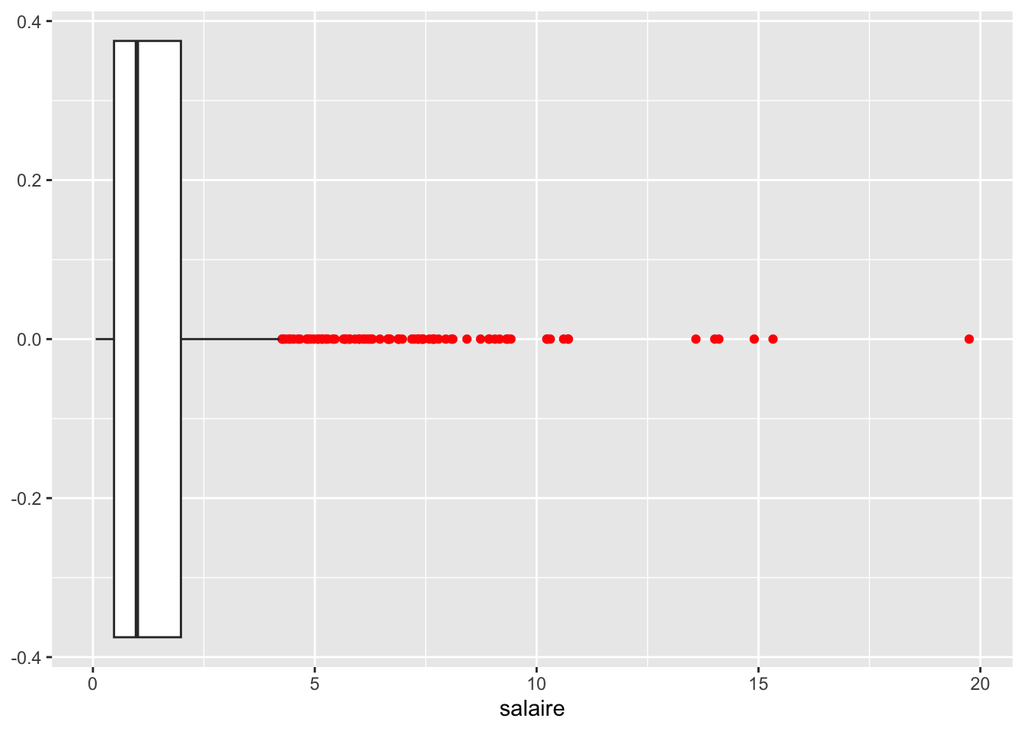

```r
# Boxplot pour distribution log normale
X<-rlnorm(1000)
ggplot(data=data.frame(salaire=X),aes(x=salaire))+
  geom_boxplot(outlier.colour = "red")
```

Exemple du jeu de données des iris

```r
data(iris)
```

# Graphes quantiles quantiles

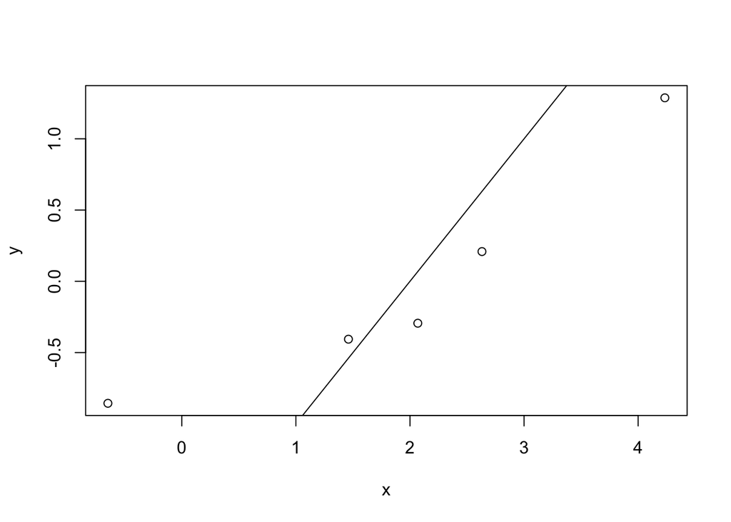

```r
x<-rnorm(50,mean=2,sd=1)
y<-rnorm(5)
qqplot(x,y)
abline(-2,1)
```

# Estimation Covariance entre deux échantillons appariés

```r
X<-iris[,1:4]
# Estimation par R
cov(X)
```

```
##              Sepal.Length Sepal.Width Petal.Length Petal.Width
## Sepal.Length    0.6856935  -0.0424340    1.2743154   0.5162707
## Sepal.Width    -0.0424340   0.1899794   -0.3296564  -0.1216394
## Petal.Length    1.2743154  -0.3296564    3.1162779   1.2956094
## Petal.Width     0.5162707  -0.1216394    1.2956094   0.5810063
```

```r
X<-scale(X,center=TRUE,scale=FALSE)
n<-nrow(X)
# Notre estimation
1/(n-1)*t(X)%*%X
```

```
##              Sepal.Length Sepal.Width Petal.Length Petal.Width
## Sepal.Length    0.6856935  -0.0424340    1.2743154   0.5162707
## Sepal.Width    -0.0424340   0.1899794   -0.3296564  -0.1216394
## Petal.Length    1.2743154  -0.3296564    3.1162779   1.2956094
## Petal.Width     0.5162707  -0.1216394    1.2956094   0.5810063
```

```r
cor(X)
```

```
##              Sepal.Length Sepal.Width Petal.Length Petal.Width
## Sepal.Length    1.0000000  -0.1175698    0.8717538   0.8179411
## Sepal.Width    -0.1175698   1.0000000   -0.4284401  -0.3661259
## Petal.Length    0.8717538  -0.4284401    1.0000000   0.9628654
## Petal.Width     0.8179411  -0.3661259    0.9628654   1.0000000
```

## Graphe de dispersion (biplot)

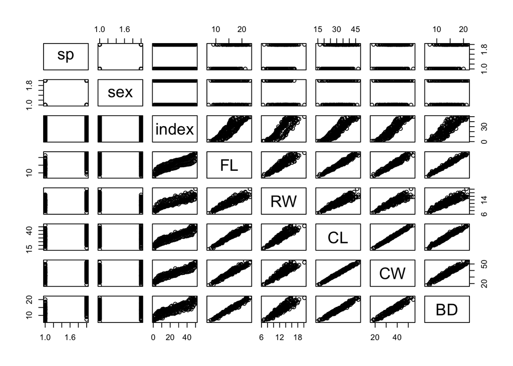

```r
library(MASS)
data(crabs)
help(crabs)
pairs(crabs)
```

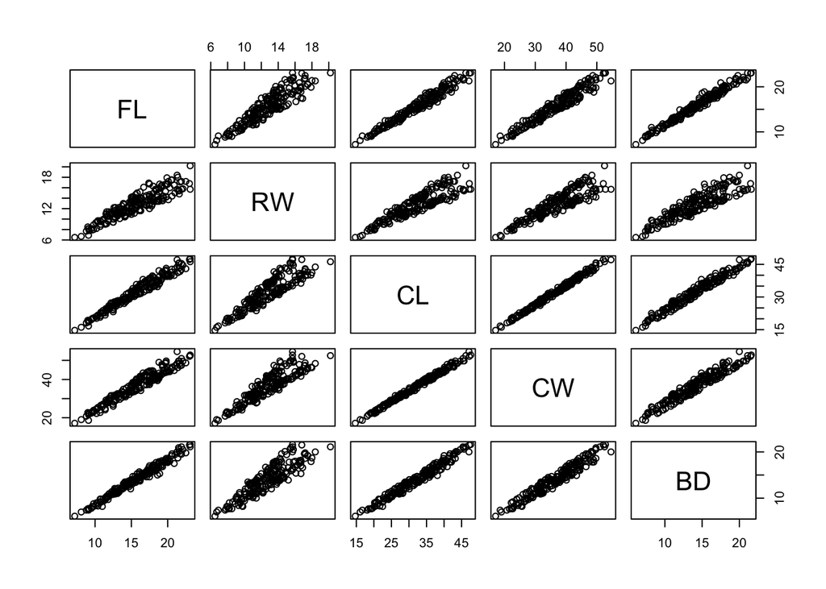

```r
pairs(crabs[,4:8])
```

```r
cor(crabs[,4:8])->correl
colMeans(correl)
```

```
##        FL        RW        CL        CW        BD
## 0.9676825 0.9178676 0.9699622 0.9656384 0.9655696
```

```r
(colSums(correl)-1)/4
```

```
##        FL        RW        CL        CW        BD
## 0.9596031 0.8973345 0.9624528 0.9570480 0.9569620
```

Faisons un changement de variables pour raisonner en relatif par rapport à la variable `longueur de carapace`. Cela permet de se focaliser sur les proportions des mesures corporelles.

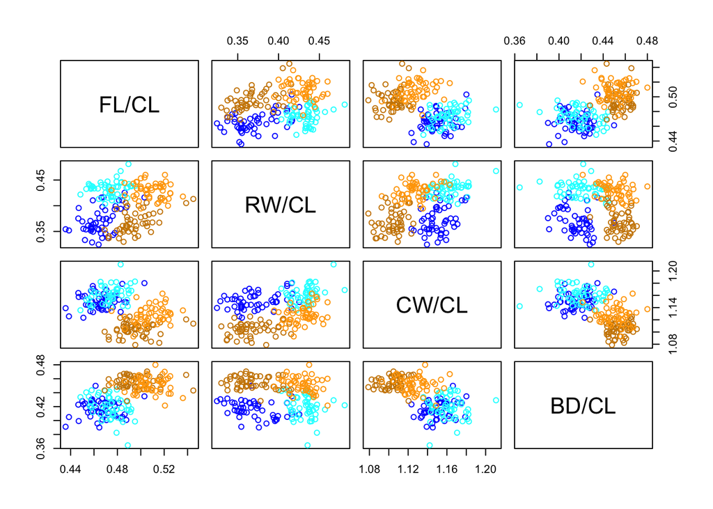

```r
crabs.new<-(crabs[,4:8]/crabs$CL)[,-3]
names(crabs.new)<-paste(names(crabs.new),"/CL",sep="")
group<-as.factor(paste(crabs$sex,crabs$sp,sep="-"))
pairs(crabs.new,col=c("cyan","orange","blue","orange3")[group])
```